# QTM 151 - Practice Quiz

**Submit as an HTML file** (see images below)

Step 1: Click the 3 dots in the toolbar for "More Actions"

[figure not shown]

Step 2: Choose "export"

[figure not shown]

Step 3: Select "HTML" from the dropdown window

[figure not shown]

Step 4: Select "Export" in the pop-up window.

[figure not shown]

Upload the .html file as your submission

Print your name below

```python
# Write your answer here

print("Caroline Zu")
```

```
Caroline Zu
```

This quiz is open book

- You can use the lecture notes
- You will get partial credit for attempting the questions
- To get full credit, the code should work as intended
- You should NOT communicate with other students

Print the following message:

"I will abide by Emory's code of conduct"

```python
# Write your answer here:
print("I will abide by Emory's code of conduct.")
```

```
I will abide by Emory's code of conduct.
```

Load in any necessary libraries/packages below:

```python
# load in necessary packages/libraries

import numpy as np
import pandas as pd
import matplotlib.pyplot as plt
```

Preliminary check: can you load the data?

In the .zip file you opened, there is a comma-separated values file named  
"HeightWeight-quiz.csv". Using Pandas, create a DataFrame object by reading in this file.

If you get an error, you must figure out what the issue is.

**Note**: This cell is just to test whether you can access the data correctly. If everything works, you can copy and paste the code later in the notebook if you prefer.

```python
# create a DataFrame by loading in the data

df_ht_wt = pd.read_csv("data_folder/HeightWeight-quiz.csv")

# You will need this for questions later.
```

(a) Making changes to a for loop

How would you change the code below, so that it prints out the position in the list of each non-numerical item it encounters?

Implement those changes, and run the code cell

```python
### Make changes to the code below

list_mixed = [1, 2, None, None, 4, 11, "Apple", 2.2, 13, "!!!", None]

i = 0
for value in list_mixed:
    if (type(value) != int) and (type(value) != float):
        print(f"Warning: Non-numerical element in position {i}")
        i = i + 1
        continue


list_mixed = [1, 2, None, None, 4, 11, "Apple", 2.2, 13, "!!!", None]

list_sum = 0
i = 0
for value in list_mixed:
    if (type(value) != int) and (type(value) != float):
        print(f"Warning: Non-numerical element in position {i}")  # use {i+1} for 1-based
    else:
        list_sum = list_sum + value
    i = i + 1

print(list_sum)
```

[output not shown]

(b) Debugging code

Below is a code which attempts to compute the sum $$1 + 2 + 3 + \cdots + (n-1) + n$$ for a positive integer $n$. For this example, we set $n = 10$. In this case, we would expect the output to be: $$ 1 + 2 + 3 + \cdots + 9 + 10 = \frac{10\times 11}{2} = 55$$

but that is not what is printed out when we run the cell below. Find the error in the code, and fix it. Then re-run the cell with $n = 19$, which should print the number $$ \frac{19\times 20}{2} = 190$$

```python
# Find the error and fix it. error was in the range, it was (0, n) which doesn't include n. should be (1, n+1)
# Then run the cell after setting n = 19
n = 19

sum_n = 0
for summands in range(1, n + 1):   #
    sum_n = sum_n + summands

print(sum_n)
```

```
190
```

c) Extracting and sorting subsets of data

In the .zip file you opened, there is a comma-separated values file named  
"HeightWeight-quiz.csv". Using Pandas, create a DataFrame object by reading in this file.

Extract rows 345 through 397 (that is, all the rows 345, 346, 347, ..., 396, 397) of the DataFrame, saving it as another DataFrame. Then sort this subset by Height (lowest to highest), assigning it to a DataFrame called `subset_sorted`

```python
# Write your answer here:
ht_wt_345to397 = df_ht_wt.iloc[344:398, :]

print(ht_wt_345to397)

subset_sorted = ht_wt_345to397.sort_values(by="Height_Inches", ascending=True)
subset_sorted = subset_sorted.reset_index(drop=True)
print(subset_sorted)
```

```
     Index  Height_Inches  Weight_Pounds
344    345       67.60582       126.1659
345    346       67.85566       138.8125
346    347       66.46536       121.5515
347    348       68.92071       114.2555
348    349       68.46886       129.4022
349    350       69.51930       137.5583
350    351       70.23956       134.4996
351    352       67.85651       127.7103
352    353       68.00435       115.6709
353    354       67.13983       131.5906
354    355       68.09931       127.5839
355    356       68.99077       125.7211
356    357       69.32618       119.9885
357    358       70.09286       140.8676
```

[output cut: 95 more lines]

(d) Filtering a data set

```python
# Write your answer here:
wt_115to140 = df_ht_wt.query("Weight_Pounds >= 115 and Weight_Pounds <= 140")
print(wt_115to140)

wt_lessthan90_ht_tallerthan72 = df_ht_wt.query("Weight_Pounds < 90 or Height_Inches >= 72")
print(wt_lessthan90_ht_tallerthan72)
```

```
       Index  Height_Inches  Weight_Pounds
1          2       71.51521       136.4873
5          6       68.69784       123.3024
7          8       70.01472       136.4623
9         10       66.78236       120.6672
10        11       66.48769       127.4516
...      ...            ...            ...
24995  24996       69.50215       118.0312
24996  24997       64.54826       120.1932
24997  24998       64.69855       118.2655
24998  24999       67.52918       132.2682
24999  25000       68.87761       124.8742

[17965 rows x 3 columns]
       Index  Height_Inches  Weight_Pounds
138      139       73.90107       151.3913
154      155       72.44434       136.7397
158      159       72.01515       138.7758
174      175       73.83364       139.2983
234      235       72.74676       135.7458
...      ...            ...            ...
24618  24619       72.47908       148.1097
24801  24802       74.53177       148.9104
24883  24884       73.06241       141.5054
24921  24922       72.54953       134.5143
24939  24940       72.35889       143.9547

[440 rows x 3 columns]
```

(e) Random Assignment

We want to divide the dataset into 3 groups randomly: group A, group B, group C

Randomly assign each person in the dataset one of three possible strings: `"A"`, `"B"`, or `"C"`. Add a column/variable to the DataFrame which contains the letter each person is assigned. Give the column/variable the name `"Group"`

**Hint**: Randomly choosing among 3 strings is not much different from randomly choosing among 4 numbers, which is what we did in Lecture 11

```python
# Write your answer here:

num_rows, num_cols = df_ht_wt.shape

group_letter = np.random.choice(["A", "B", "C"], size = num_rows)

print(group_letter.shape)
df_ht_wt["Group"] = group_letter
```

```
(25000,)
```

(f) Plotting data from one the groups

Create a new DataFrame by extracting all rows corresponding to Group B. Then make a scatter plot of height vs. weight (height on horizontal axis, weight on vertical axis) for the people in this group.

Give appropriate labels to the axes and give your scatter plot a reasonable title.

```
       Index  Height_Inches  Weight_Pounds Group
1          2       71.51521       136.4873     B
8          9       67.90265       112.3723     B
12        13       68.30248       125.6107     B
13        14       67.11656       122.4618     B
20        21       67.83379       141.2807     B
...      ...            ...            ...   ...
24985  24986       69.71587       133.9126     B
24987  24988       68.86794       142.8494     B
24989  24990       70.11839       141.2370     B
24990  24991       69.97767       125.3672     B
24996  24997       64.54826       120.1932     B

[8404 rows x 4 columns]
```

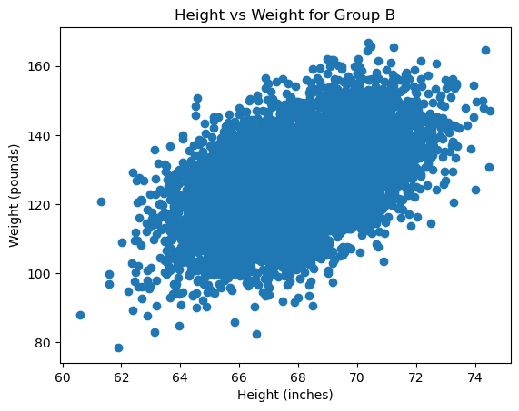

```python
# Write your answer here:
subset_groupB = df_ht_wt.query("Group == 'B'")
print(subset_groupB)

plt.scatter(x = subset_groupB["Height_Inches"], y = subset_groupB["Weight_Pounds"])
plt.xlabel("Height (inches)")
plt.ylabel("Weight (pounds)")
plt.title("Height vs Weight for Group B")
plt.show()
```

(g) Convert your notebook to .html

Convert your notebook to .html format. You will be expected to submit your quiz in this format, so now is the time to make sure you can do it. Instructions are at the top of this notebook.

**A small point deduction will be taken off for submissions in the wrong format**